# Trabajo Práctico AID

Author

Milagros Terán

# Introducción

A lo largo de este trabajo, se muestra un análisis realizado sobre una base de datos obtenida del sitio web Kaggle, en el que se analizan terremotos y su características, así como la presencia o ausencia de tsunamis una vez sucedidos los terremotos. El siguiente análisis, se va a focalizar en la variable objetivo de Tsunami.

## Limpieza de Datos

Se comenzó con la limpieza de los datos del dataset llamado Earthquake_data_tsunami. El mismo es un archivo csv.

Los pasos que se siguieron fueron los siguientes:

1. Cargar el dataset → utilizando read_delim
2. Usar str() → Para ver qué tipo de datos tiene cada columna.

   A partir de la salida del str(), se observó que todos los datos están clasificados como numéricos. Habiendo visto las variables en el dataset, y leído sus descripciones, se decidió que más adelante, se convierta a las correspondientes variables en factores para su posterior análisis.
3. Revisar valores faltantes (NA) → colSums(is.na(datos))

Se confirma, que no hay valores NA en el dataset.

4. Revisar valores fuera de rango → summarise() con los límites proporcionados.

Se confirma, que no hay valores fuera de los rangos establecidos en el dataset.

5. Limpiar los datos → Eliminar o corregir registros con errores. En este caso, este paso no fue necesario debido a que no había valores fuera de rango ni faltantes.
6. Convertir tipos de variables → Las variables MMI, CDI, Tsunami y Month fueron convertidas a factor.

Las variables *MMI y CDI*, se convierten porque representan niveles de intensidad en una escala jerárquica. Esto hace que se reconozca su orden y no se traten simplemente como números continuos.

Se convierte en factor nominal a la variable *Month*, porque al pasarlos a factor con etiquetas, se evita que R los interprete como valores cuantitativos y facilita la visualización y el análisis de frecuencias.

Por último, la variable dicotómica *Tsunami*, se convierte en factor con etiquetas (“Sí”/“No”) para que los gráficos y tablas sean más interpretables y para que los modelos estadísticos lo traten como una variable binaria en lugar de como un número.

## Exploración de los Datos

Se comenzó esta parte del análisis, investigando la cantidad de observaciones y variables presentes en el dataset.

Se observaron 782 observaciones y 13 variables.

Los nombres de las variables son:

- Magnitude: Magnitud del terremoto (escala Ritcher)
- CDI: Intensidad percibida por la comunidad
- MMI: Intensidad instrumental
- SIG: Puntaje de significancia del evento
- NST: Número de estaciones sísmicas que registraron el evento
- DMIN: Distancia a la estación sísmica más cercana (en grados)
- GAP: Brecha azimutal entre estaciones (en grados)
- Depth: Profundidad focal del terremoto (en km)
- Latitude: Latitud del epicentro (WGS84)
- Longitude: Longitud del epicentro (WGS84)
- Year: Año de ocurrencia del evento
- Month: Mes de ocurrencia del evento
- Tsunami: Presencia de tsunami

### Exploración general del dataset

Se observan 782 observaciones y 13 variables. También se puede confirmar, que están correctamente clasificadas: CDI, MMI, Month y Tsunami son factores.

```r
# Resumen estadístico general
summary(datos)
```

```
   magnitude          cdi           mmi           sig              nst
 Min.   :6.500   0      :212   7      :209   Min.   : 650.0   Min.   :  0.0
 1st Qu.:6.600   5      :107   6      :203   1st Qu.: 691.0   1st Qu.:  0.0
 Median :6.800   7      : 97   5      :142   Median : 754.0   Median :140.0
 Mean   :6.941   8      : 86   4      : 87   Mean   : 870.1   Mean   :230.3
 3rd Qu.:7.100   6      : 77   8      : 68   3rd Qu.: 909.8   3rd Qu.:445.0
 Max.   :9.100   9      : 66   3      : 40   Max.   :2910.0   Max.   :934.0
                 (Other):137   (Other): 33
      dmin             gap             depth           latitude
 Min.   : 0.000   Min.   :  0.00   Min.   :  2.70   Min.   :-61.848
 1st Qu.: 0.000   1st Qu.: 14.62   1st Qu.: 14.00   1st Qu.:-14.596
 Median : 0.000   Median : 20.00   Median : 26.30   Median : -2.572
 Mean   : 1.326   Mean   : 25.04   Mean   : 75.88   Mean   :  3.538
 3rd Qu.: 1.863   3rd Qu.: 30.00   3rd Qu.: 49.75   3rd Qu.: 24.654
 Max.   :17.654   Max.   :239.00   Max.   :670.81   Max.   : 71.631

   longitude            Year          Month     tsunami
 Min.   :-179.97   Min.   :2001   Sep    : 80   No:478
 1st Qu.: -71.67   1st Qu.:2007   Nov    : 80   Sí:304
 Median : 109.43   Median :2013   Abr    : 77
 Mean   :  52.61   Mean   :2012   Ene    : 70
 3rd Qu.: 148.94   3rd Qu.:2017   Oct    : 69
 Max.   : 179.66   Max.   :2022   Ago    : 68
                                  (Other):338
```

Este análisis inicial, ofrece una visión general de la distribución de las variables. En las siguientes secciones se profundiza en el análisis estadístico de cada variable, y en la relación de cada una con la ocurrencia de tsunamis, mediante pruebas estadísticas y visualizaciones correspondientes.

**Magnitude**

*Estadísticos descriptivos*

```
   Min. 1st Qu.  Median    Mean 3rd Qu.    Max.
  6.500   6.600   6.800   6.941   7.100   9.100
```

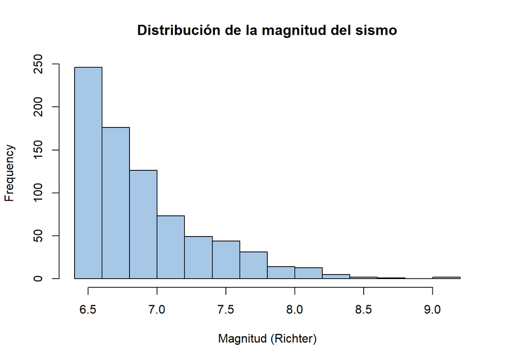

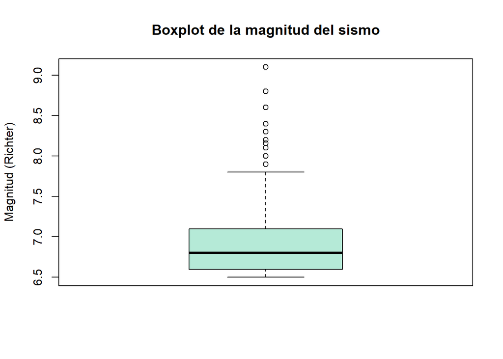

*Análisis*: Se observa que la mayoría de los eventos tienen magnitudes moderadas, concentradas entre 6.5 y 6.8 aproximadamente. La media es ligeramente superior a la mediana, lo que sugiere una distribución asimétrica positiva, la cual se refuerza al ver los gráficos, con algunos eventos de magnitud elevada que actúan como outliers.

**Depth**

*Estadísticos descriptivos*

```
   Min. 1st Qu.  Median    Mean 3rd Qu.    Max.
   2.70   14.00   26.30   75.88   49.75  670.81
```

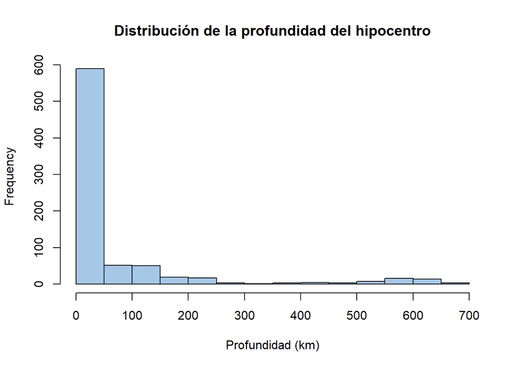

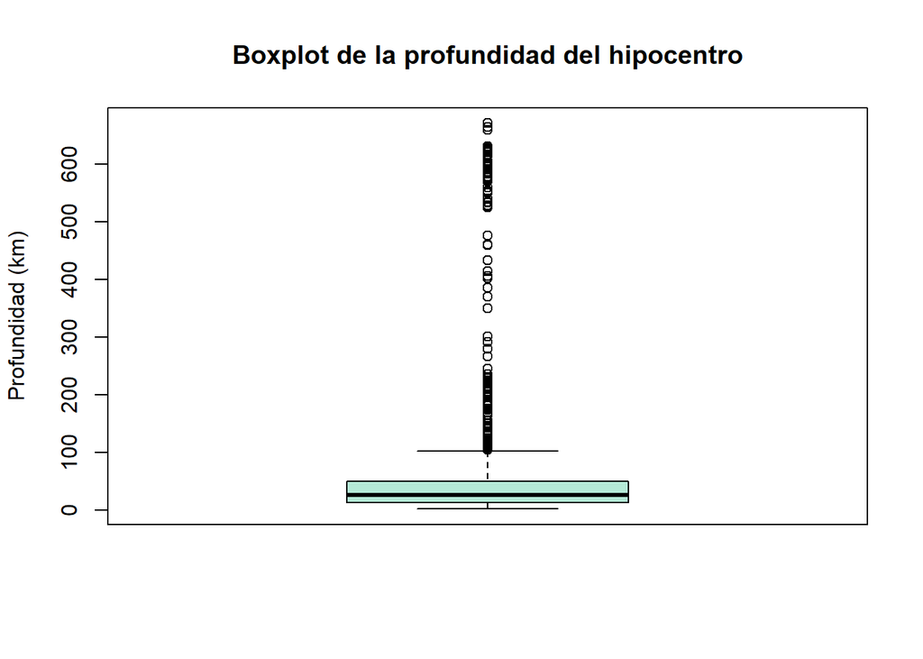

*Análisis*: Se observa que su distribución muestra una fuerte concentración de eventos a baja profundidad: el 50% de los sismos ocurren por debajo de los 26.3 km, con un mínimo de 2.7 km. Sin embargo, la media asciende a 75.88 km, lo que indica una asimetría a la derecha causada por varios eventos profundos. El histograma refleja esta concentración en bajas profundidades y una larga cola hacia la derecha, mientras que el boxplot confirma la presencia de varios outliers profundos.

**Dmin**

*Estadísticos descriptivos*

```
   Min. 1st Qu.  Median    Mean 3rd Qu.    Max.
  0.000   0.000   0.000   1.326   1.863  17.654
```

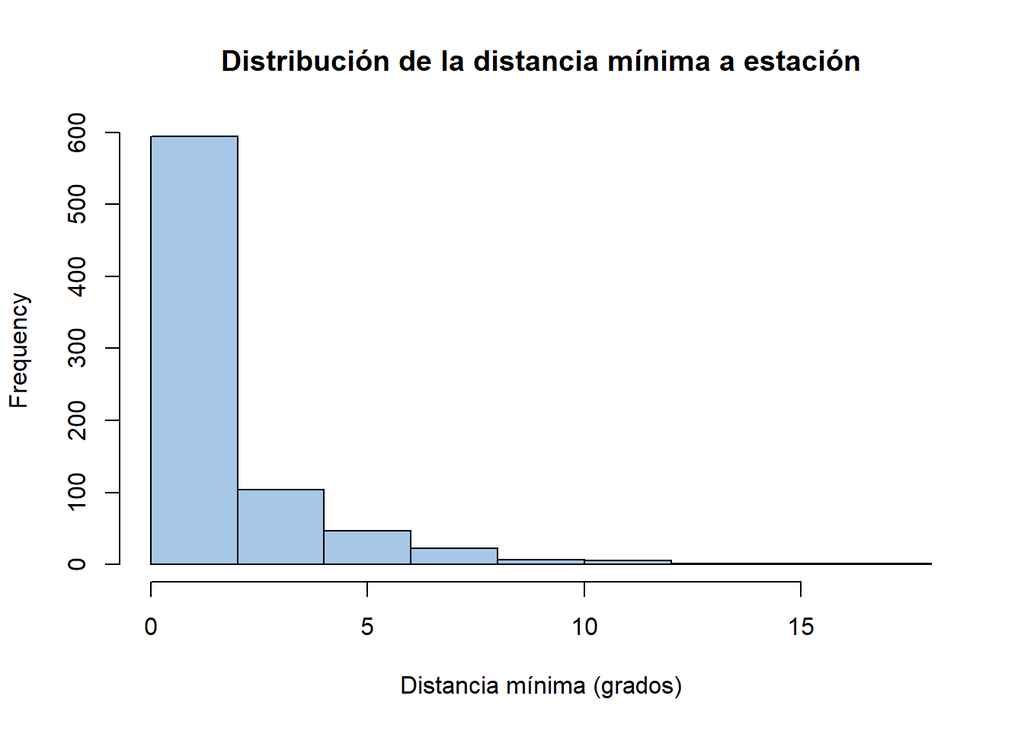

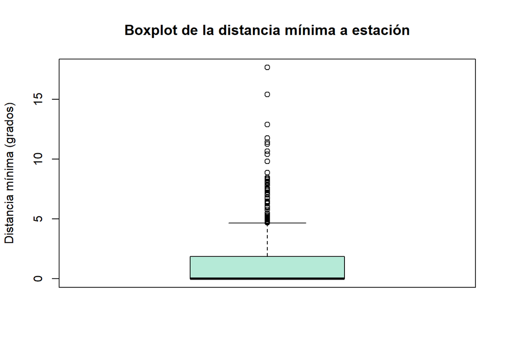

*Análisis*: Se observa una fuerte concentración de valores en cero: tanto el mínimo, el primer cuartil como la mediana son 0. Esto indica que en muchos casos el epicentro coincide con una estación o está muy cerca. Sin embargo, la media llega a 1.33 grados y el valor máximo es 17.65, lo que confirma una asimetría positiva. El histograma confirma esta concentración extrema en valores bajos, mientras que el boxplot muestra varios outliers que podrían influir en la calidad del registro.

**Gap**

*Estadísticos descriptivos*

```
   Min. 1st Qu.  Median    Mean 3rd Qu.    Max.
   0.00   14.62   20.00   25.04   30.00  239.00
```

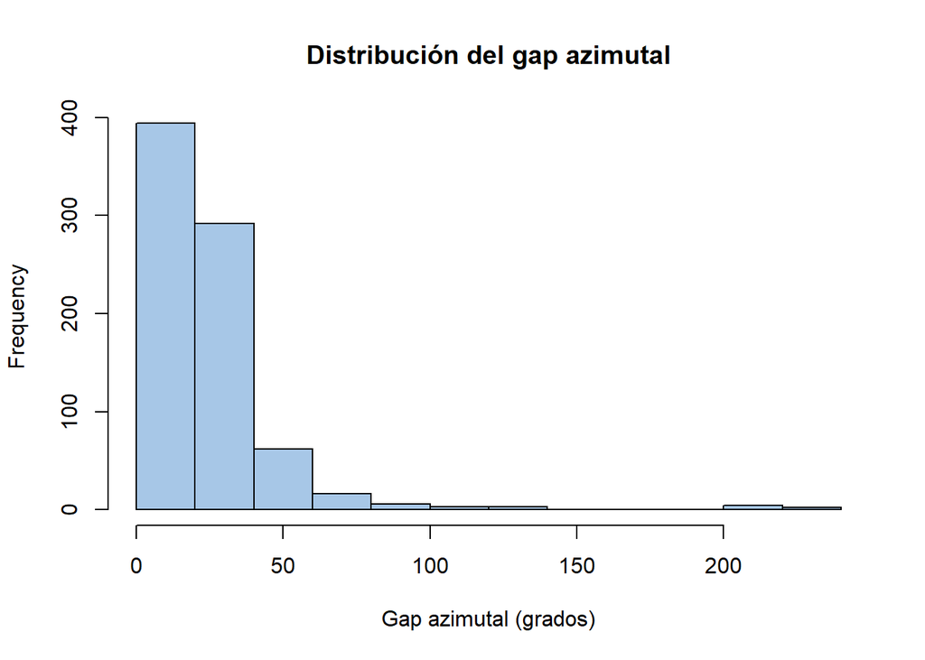

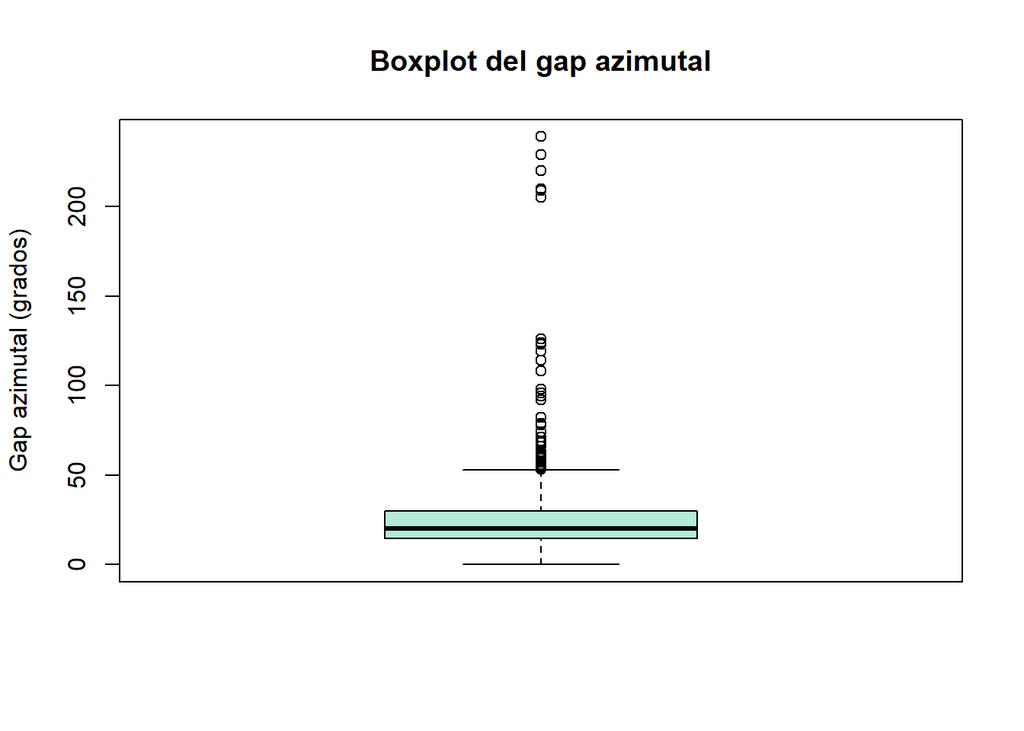

*Análisis*: Esta variable refleja la cobertura angular del evento de las estaciones: a valores bajos, mejor cobertura, mientras que valores altos pueden indicar zonas mal monitoreadas. El 50% de los datos tuvieron menos de 20° y la media es de 25°, con un rango que va desde 0° hasta 239°. La distribución es asimétrica positiva, con la mayoría de los eventos concentrados por debajo de los 50°, como se observa en el histograma. El boxplot muestra varios outliers con valores elevados, lo que podría afectar la precisión en la localización del epicentro.

**Latitude**

*Estadísticos descriptivos*

```
   Min. 1st Qu.  Median    Mean 3rd Qu.    Max.
-61.848 -14.596  -2.572   3.538  24.654  71.631
```

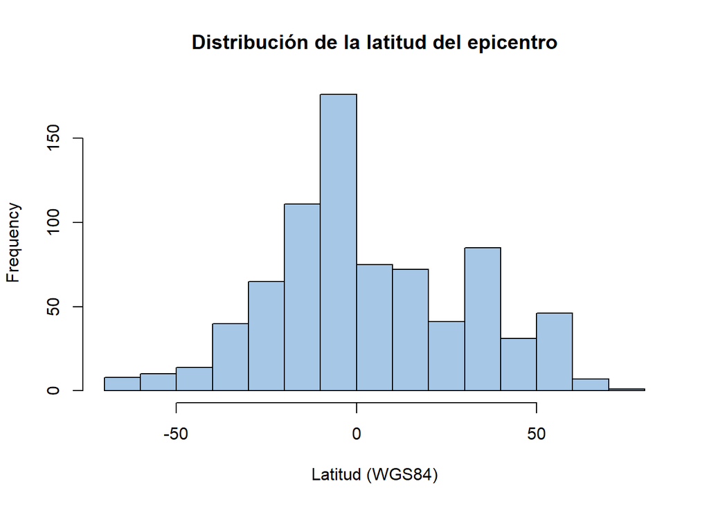

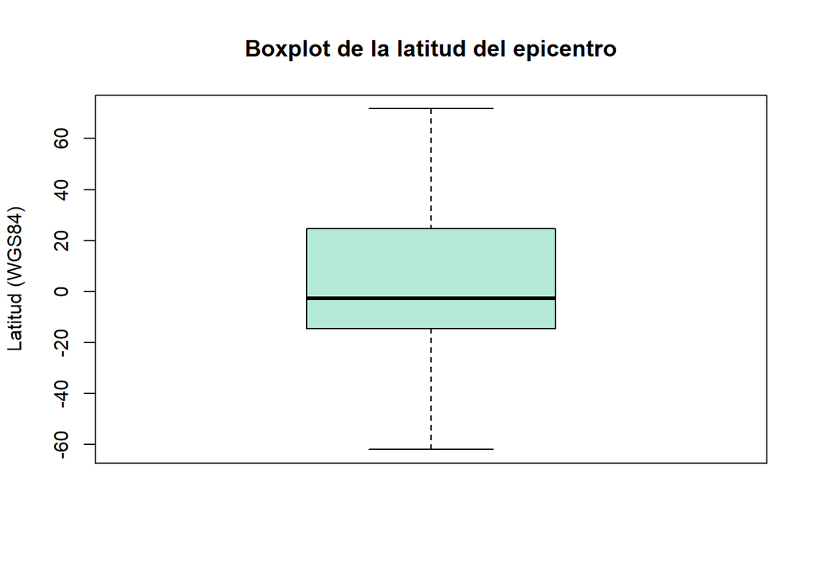

**Longitude**

*Estadísticos descriptivos*

```
   Min. 1st Qu.  Median    Mean 3rd Qu.    Max.
-179.97  -71.67  109.43   52.61  148.94  179.66
```

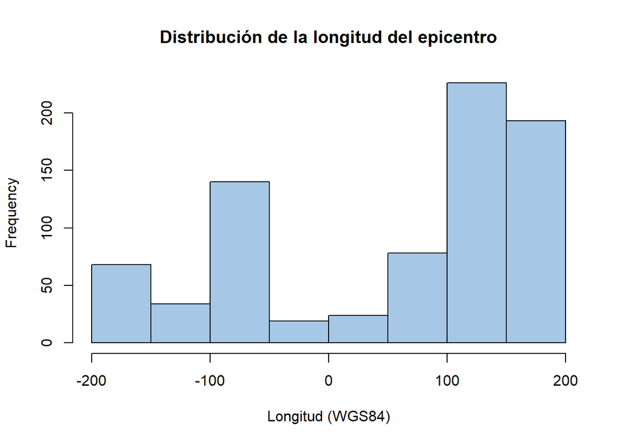

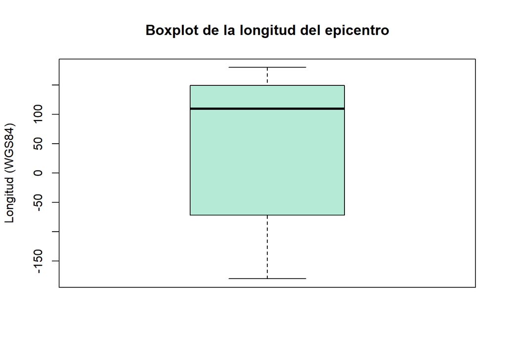

*Análisis*: La variable longitud de los epicentros muestra una distribución amplia, que abarca desde aproximadamente −180° hasta +180°, lo que indica que los eventos sísmicos se registraron en todo el globo, tanto en zonas del hemisferio occidental como oriental. La mediana (aprox. 109.43°) y la media (aprox. 52.61°) sugieren una mayor concentración de eventos en regiones del este. El histograma revela una distribución bimodal, con acumulaciones tanto en valores negativos como positivos, mientras que el boxplot confirma la dispersión sin presencia de valores atípicos extremos.

**Sig**

*Estadísticos descriptivos*

```
   Min. 1st Qu.  Median    Mean 3rd Qu.    Max.
  650.0   691.0   754.0   870.1   909.8  2910.0
```

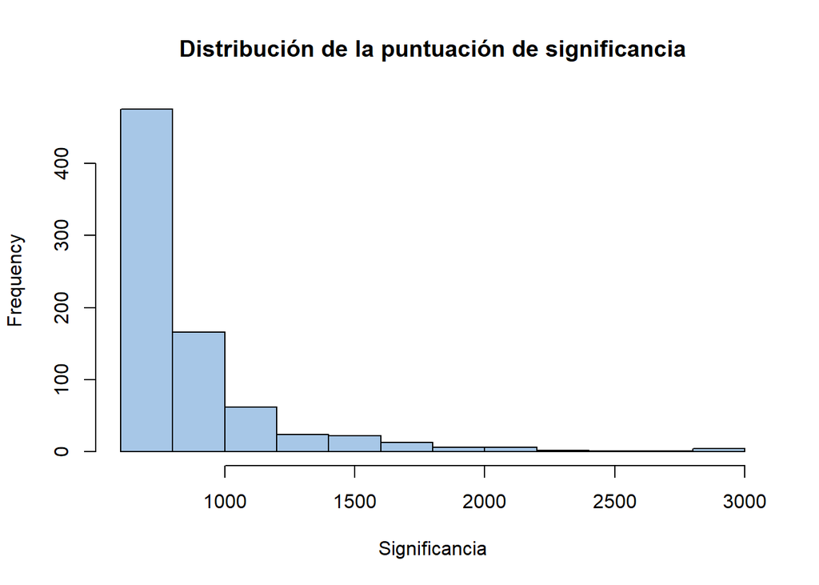

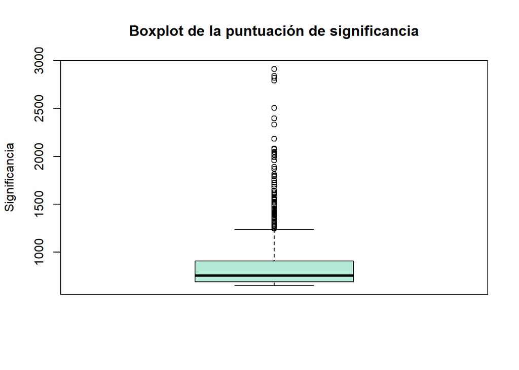

*Análisis*: La variable significancia (sig) presenta una distribución muy asimétrica hacia la derecha, con valores que oscilan entre 650 y 2910. El histograma muestra una concentración de eventos en el rango bajo (650–1000), mientras que el boxplot muestra múltiples valores atípicos en el extremo superior. Esta dispersión sugiere que, aunque la mayoría de los eventos tienen una significancia moderada, existen algunos casos que podrían corresponder a sismos de gran impacto o relevancia geofísica.

**NST**

*Estadísticos descriptivos*

```
   Min. 1st Qu.  Median    Mean 3rd Qu.    Max.
    0.0     0.0   140.0   230.3   445.0   934.0
```

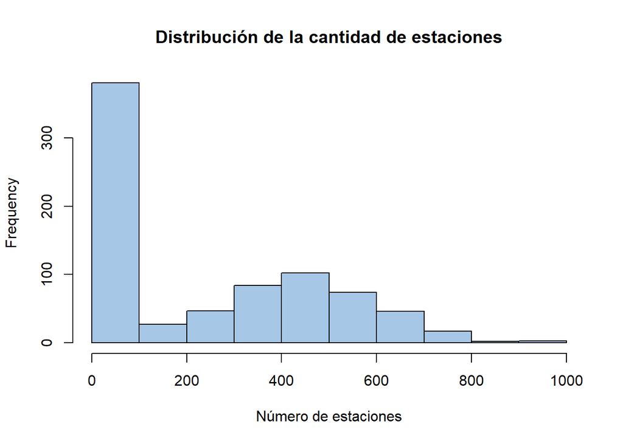

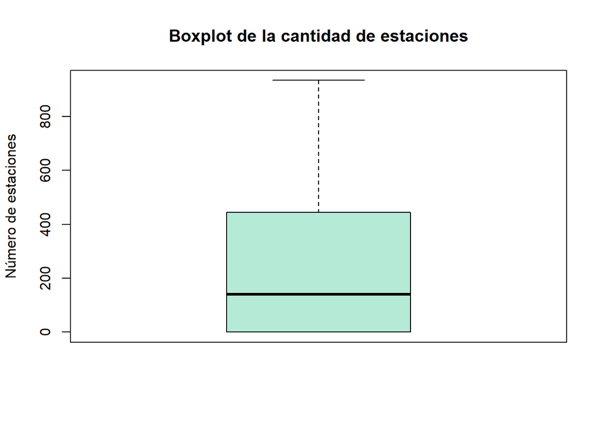

**Year**

*Estadísticos descriptivos*

```
   Min. 1st Qu.  Median    Mean 3rd Qu.    Max.
   2001    2007    2013    2012    2017    2022
```

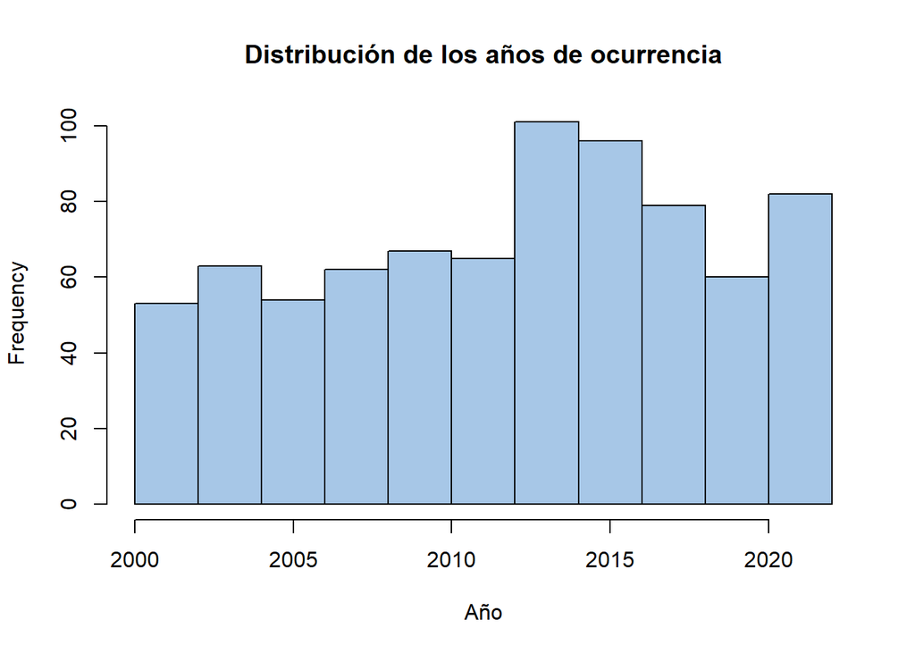

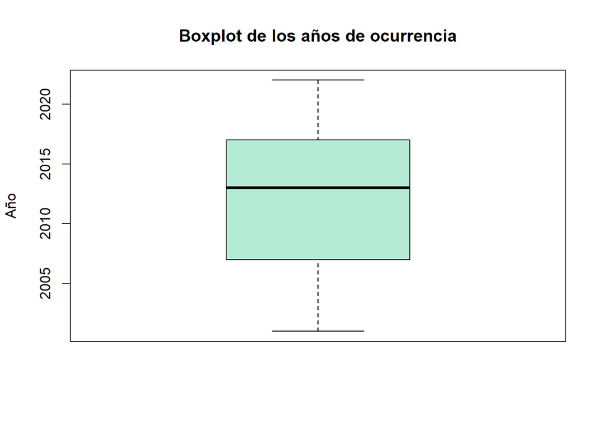

**MMI**

*Estadísticos descriptivos*

```
  1   2   3   4   5   6   7   8   9
  1   4  40  87 142 203 209  68  28
```

```
          1           2           3           4           5           6
0.001278772 0.005115090 0.051150895 0.111253197 0.181585678 0.259590793
          7           8           9
0.267263427 0.086956522 0.035805627
```

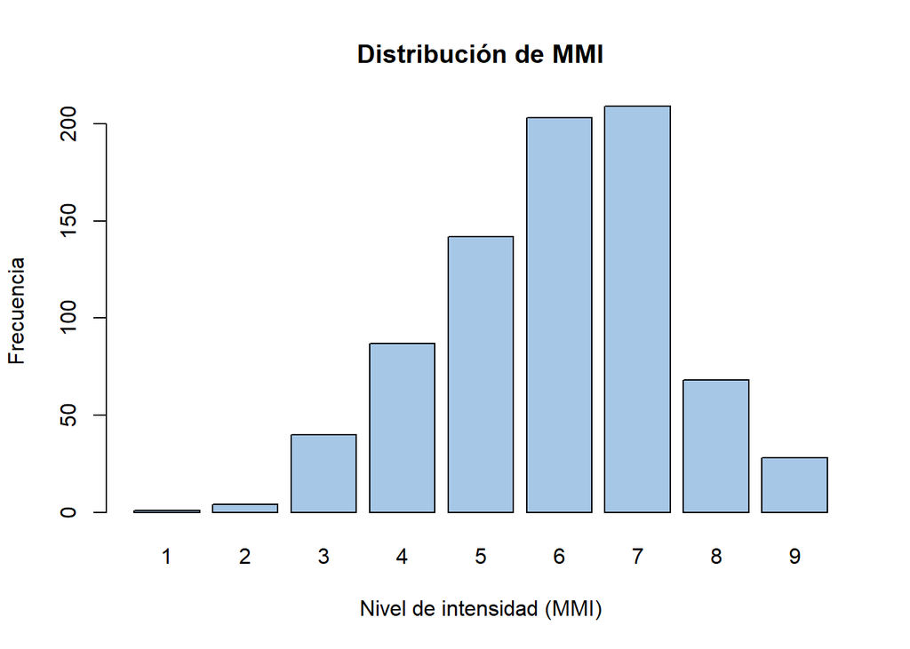

*Análisis*: La variable MMI representa la intensidad instrumental de los eventos sísmicos, medida en una escala ordinal de 1 a 9. El gráfico muestra una distribución claramente sesgada hacia los niveles altos, con mayor frecuencia en los valores 6 y 7. Esto indica que la mayoría de los sismos del conjunto de datos fueron percibidos con intensidad considerable. Los niveles bajos (1 a 3) son poco frecuentes, lo que sugiere que el dataset está compuesto principalmente por eventos importantes desde el punto de vista instrumental.

**CDI**

*Estadísticos descriptivos*

```
  0   1   2   3   4   5   6   7   8   9
212  14  14  47  62 107  77  97  86  66
```

```
         0          1          2          3          4          5          6
0.27109974 0.01790281 0.01790281 0.06010230 0.07928389 0.13682864 0.09846547
         7          8          9
0.12404092 0.10997442 0.08439898
```

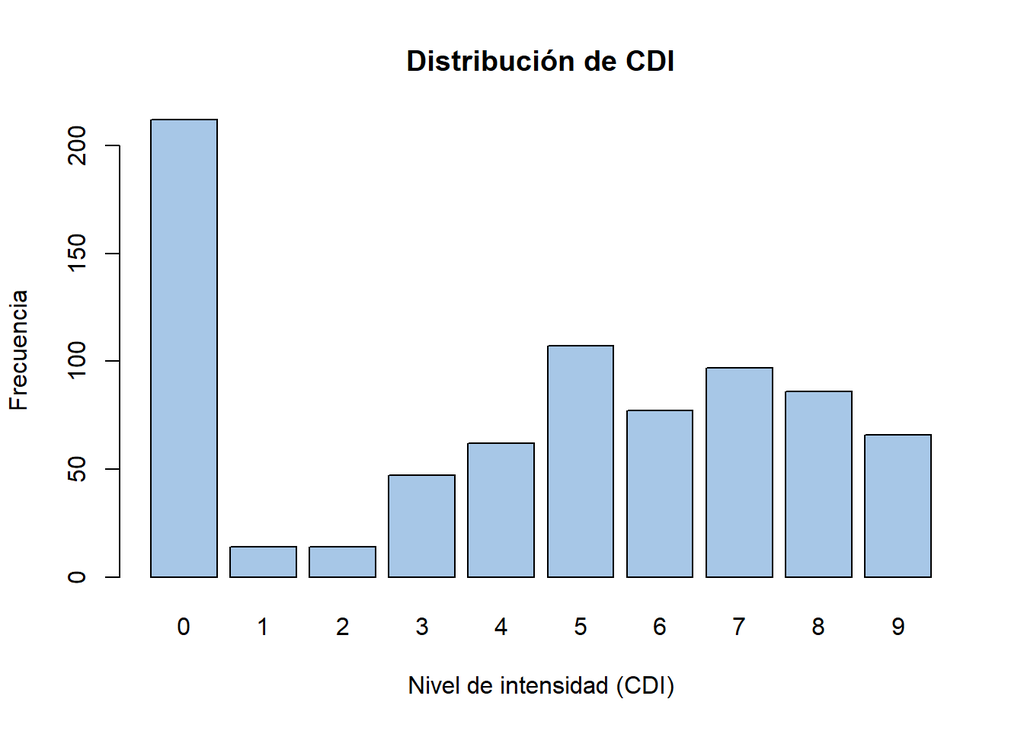

*Análisis*: La variable CDI representa la intensidad percibida por la población durante los eventos sísmicos, en una escala ordinal de 0 a 9. El histograma muestra una distribución con una marcada concentración en el nivel 0 (27% de los casos), lo que indica que una gran proporción de eventos no fueron percibidos por la comunidad. Sin embargo, también se observa una presencia significativa en niveles intermedios como 5, 6 y 7, que en conjunto representan más del 35% del total. Esta dispersión sugiere que, aunque muchos sismos fueron instrumentales, una parte considerable tuvo impacto perceptible.

**Month**

*Estadísticos descriptivos*

```
Ene Feb Mar Abr May Jun Jul Ago Sep Oct Nov Dic
 70  63  63  77  58  42  56  68  80  69  80  56
```

```
       Ene        Feb        Mar        Abr        May        Jun        Jul
0.08951407 0.08056266 0.08056266 0.09846547 0.07416880 0.05370844 0.07161125
       Ago        Sep        Oct        Nov        Dic
0.08695652 0.10230179 0.08823529 0.10230179 0.07161125
```

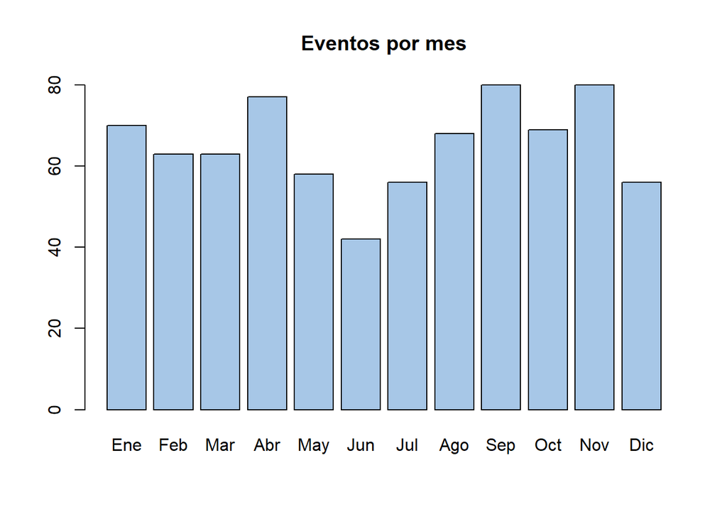

*Análisis*: El histograma muestra una distribución relativamente equilibrada a lo largo del año, aunque se observan picos en septiembre y noviembre (80 eventos cada uno), y una menor frecuencia en junio (42 eventos). Esta variabilidad mensual podría deberse a factores geológicos o al momento del monitoreo.

**Tsunami**

*Estadísticos descriptivos*

```
 No  Sí
478 304
```

```
       No        Sí
0.6112532 0.3887468
```

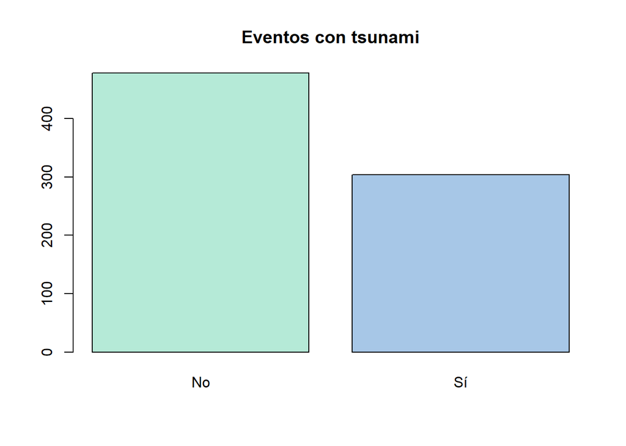

*Análisis*: Del total de registros, aproximadamente el 39% de los eventos estuvieron acompañados por un tsunami (304 casos), mientras que el 61% no lo estuvieron (478 casos). Es decir, no todos los terremotos terminan en tsunamis, pero son suficientes para ser analizados.

### Análisis enfocado en Tsunami

**Tsunami vs Magnitude**

*Boxplot y t.test*

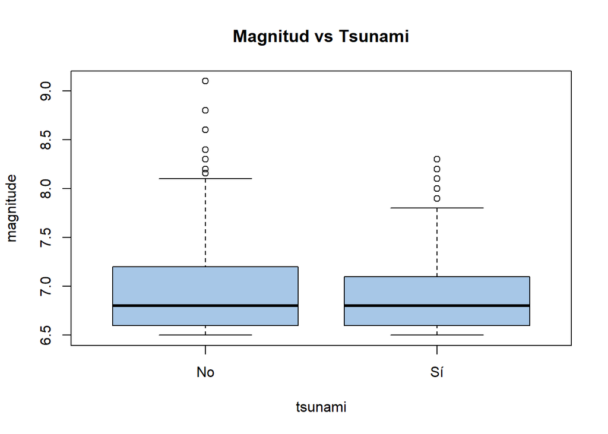

```
    Welch Two Sample t-test

data:  magnitude by tsunami
t = 0.13443, df = 683.57, p-value = 0.8931
alternative hypothesis: true difference in means between group No and group Sí is not equal to 0
95 percent confidence interval:
 -0.05873024  0.06736325
sample estimates:
mean in group No mean in group Sí
        6.942803         6.938487
```

*Análisis*: El test de Welch no detectó diferencias significativas en la magnitud promedio entre los eventos sísmicos que generaron tsunami y aquellos que no (p = 0.8931), lo que sugiere que la magnitud, por sí sola, no constituye un buen predictor de la ocurrencia de tsunamis.

Esta conclusión se ve reforzada por el boxplot comparativo, donde ambas distribuciones presentan rangos similares, medianas prácticamente iguales y una dispersión homogénea.

**Tsunami vs Depth**

*Boxplot y t.test*

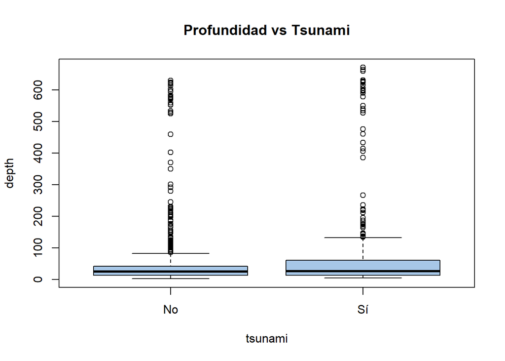

```
    Welch Two Sample t-test

data:  depth by tsunami
t = -1.5309, df = 565.91, p-value = 0.1264
alternative hypothesis: true difference in means between group No and group Sí is not equal to 0
95 percent confidence interval:
 -36.504637   4.525756
sample estimates:
mean in group No mean in group Sí
        69.66736         85.65680
```

*Análisis*: Aunque los eventos con tsunami presentan una profundidad promedio ligeramente mayor, el test de Welch no detectó diferencias estadísticamente significativas entre ambos grupos (p = 0.1264). El boxplot confirma esto, mostrando mayor dispersión en el grupo con tsunami, pero sin una diferencia clara entre las distribuciones. Esto sugiere que la profundidad, si bien podría influir en ciertos casos, no constituye un factor determinante por sí sola en la ocurrencia de tsunamis.

**Tsunami vs Latitude y Longitude**

*Gráfico de dispersión*

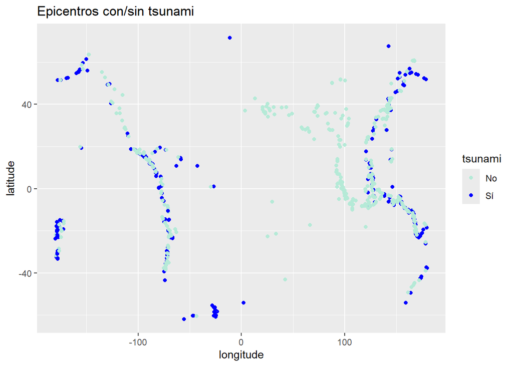

**Tsunami vs NST**

*Resumen estadístico y Boxplot*

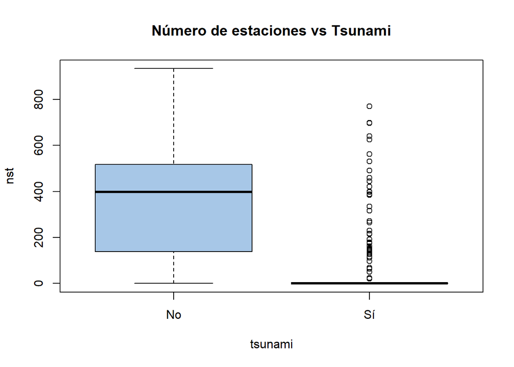

Resumen estadístico del número de estaciones por grupo de tsunami

| tsunami | Media | Mediana | Rango_IQ | Min | Max | N |
| --- | --- | --- | --- | --- | --- | --- |
| No | 349.9 | 397 | 378.5 | 0 | 934 | 478 |
| Sí | 42.1 | 0 | 0.0 | 0 | 770 | 304 |

*Análisis*: El número de estaciones que registraron los eventos muestra una diferencia marcada entre los grupos. Los sismos sin tsunami presentan mayor cobertura instrumental, mientras que los eventos con tsunami tienden a ocurrir en zonas con menor densidad de estaciones. Esta diferencia podría estar asociada a la localización geográfica de los epicentros. La tabla comparativa refuerza la diferencia observada en el boxplot: los eventos con tsunami presentan una cobertura instrumental significativamente menor, con una mediana de estaciones igual a cero. Esto sugiere que estos eventos ocurren con frecuencia en zonas alejadas de redes sísmicas densas, como regiones oceánicas, lo que podría dificultar su detección temprana y contribuir a su peligrosidad.

**Tsunami vs DMIN**

*Resumen estadístico y Boxplot*

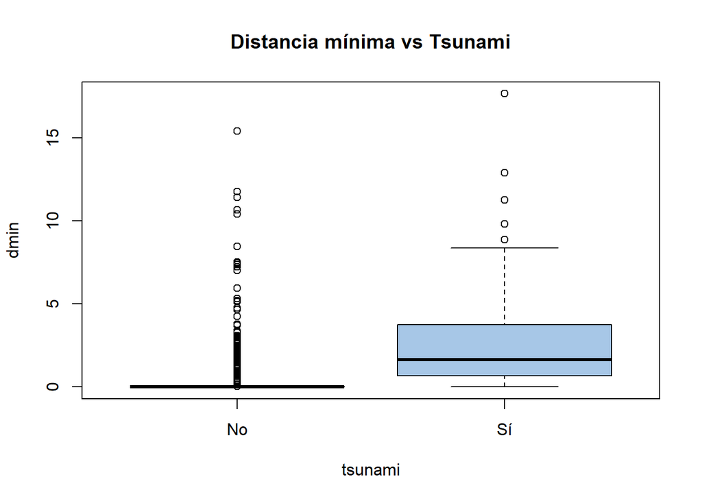

Estadísticas descriptivas de la distancia mínima (dmin) según presencia de tsunami

| tsunami | Media | Mediana | IQR |
| --- | --- | --- | --- |
| No | 0.6 | 0.0 | 0.0 |
| Sí | 2.4 | 1.6 | 3.1 |

*Análisis*: En los eventos sísmicos que generaron tsunamis se observa, en promedio, una mayor distancia mínima respecto a las estaciones sísmicas en comparación con aquellos que no generan tsunamis. Esta diferencia aparece tanto en la media como en la mediana y se acompaña de una mayor dispersión (IQR), lo que indica que estos eventos tienden a localizarse en zonas más remotas y heterogéneas. Tal comportamiento puede estar relacionado con su ocurrencia en áreas oceánicas con menor densidad de monitoreo, lo cual reduce la precisión del registro instrumental.

**Tsunami vs GAP**

*Resumen estadístico y Boxplot*

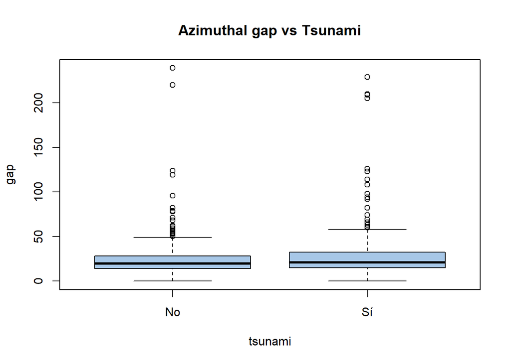

Estadísticas descriptivas del azimuthal gap según presencia de tsunami

| tsunami | Media | Mediana | IQR |
| --- | --- | --- | --- |
| No | 22.8 | 19.5 | 14.0 |
| Sí | 28.6 | 21.0 | 17.2 |

*Análisis*: Los eventos que generaron tsunamis presentan, en promedio, valores más altos de azimuthal gap que los no asociados. Esta diferencia se refleja tanto en la media como en la mediana, y también en el rango intercuartílico, lo que indica una mayor dispersión. Esto sugiere que los eventos con tsunami tienden a ocurrir en zonas con menor cobertura angular de estaciones sísmicas, posiblemente en regiones oceánicas o lejanas. Esto aporta información sobre la calidad del registro instrumental, que es importante para interpretar los datos con mejor contexto.

**Tsunami vs SIG**

*Resumen estadístico y t.test*

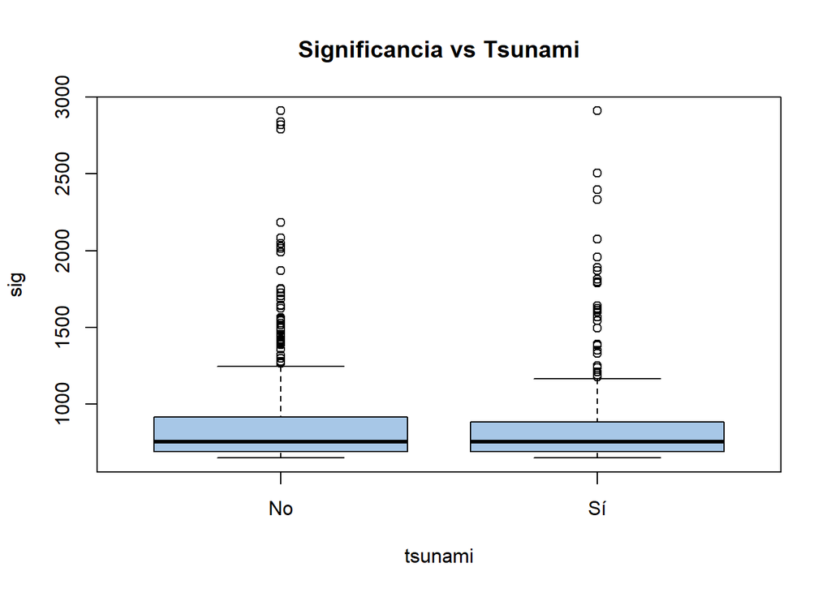

```
    Welch Two Sample t-test

data:  sig by tsunami
t = 0.43489, df = 654.78, p-value = 0.6638
alternative hypothesis: true difference in means between group No and group Sí is not equal to 0
95 percent confidence interval:
 -36.01883  56.51215
sample estimates:
mean in group No mean in group Sí
        874.0921         863.8454
```

*Análisis*: Según el test de Welch, no se observa una diferencia estadísticamente significativa en los valores de significancia (sig) entre los eventos con y sin tsunami (p = 0.66). Las medias son similares (874.1 para eventos sin tsunami y 863.8 para los con), y el intervalo de confianza incluye el cero, lo que refuerza la idea de que no hay evidencia suficiente para afirmar que el comportamiento de sig varía según la presencia de tsunami. Esto sugiere que esta variable no estaría aportando información relevante para diferenciar ambos tipos de eventos en este contexto.

**Tsunami vs CDI**

*Chi cuadrado y gráfico de barras*

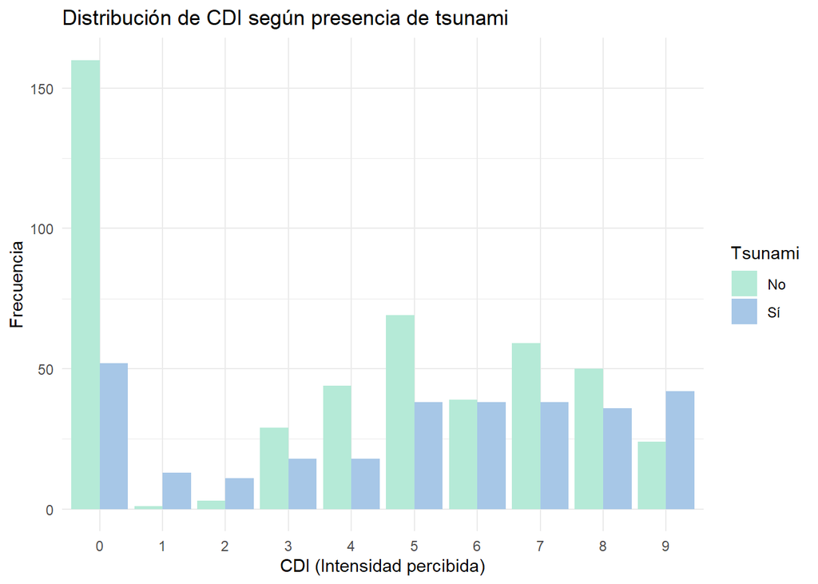

```
    Pearson's Chi-squared test

data:  table(datos$cdi, datos$tsunami)
X-squared = 68.771, df = 9, p-value = 2.65e-11
```

```
     No  Sí
  0 160  52
  1   1  13
  2   3  11
  3  29  18
  4  44  18
  5  69  38
  6  39  38
  7  59  38
  8  50  36
  9  24  42
```

*Análisis*: La distribución de los niveles de intensidad percibida (CDI) varía según la presencia de tsunami. Mientras que los eventos sin tsunami se concentran en niveles bajos (especialmente en CDI 0), los eventos con tsunami muestran una mayor frecuencia en niveles intermedios y altos. Esta diferencia fue confirmada estadísticamente mediante el test de Chi-cuadrado (X² = 68.77, p < 0.001), lo que indica una asociación significativa entre la intensidad percibida y la ocurrencia de tsunamis.

**Tsunami vs MMI**

*Chi cuadrado y gráfico de barras*

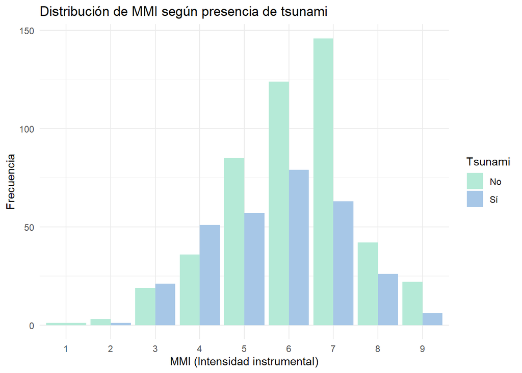

```
    Pearson's Chi-squared test

data:  table(datos$mmi, datos$tsunami)
X-squared = 28.76, df = 8, p-value = 0.0003494
```

```
       1   2   3   4   5   6   7   8   9
  No   1   3  19  36  85 124 146  42  22
  Sí   0   1  21  51  57  79  63  26   6
```

*Análisis*: La distribución de la intensidad instrumental (MMI) muestra diferencias marcadas según la presencia de tsunami. Los eventos sin tsunami se concentran en niveles altos (especialmente MMI 6 y 7), mientras que los eventos con tsunami presentan una distribución más repartida, con mayor frecuencia en niveles intermedios. El test de Chi-cuadrado confirma esta diferencia (X² = 28.76, p < 0.001), lo que indica una asociación significativa entre MMI y la ocurrencia de tsunamis. Esto sugiere que, si bien los tsunamis pueden estar presentes en eventos intensos, también se vinculan con sismos de menor intensidad, probablemente por su localización o características específicas.

**Tsunami vs Year**

*Tabla y gráfico de barras*

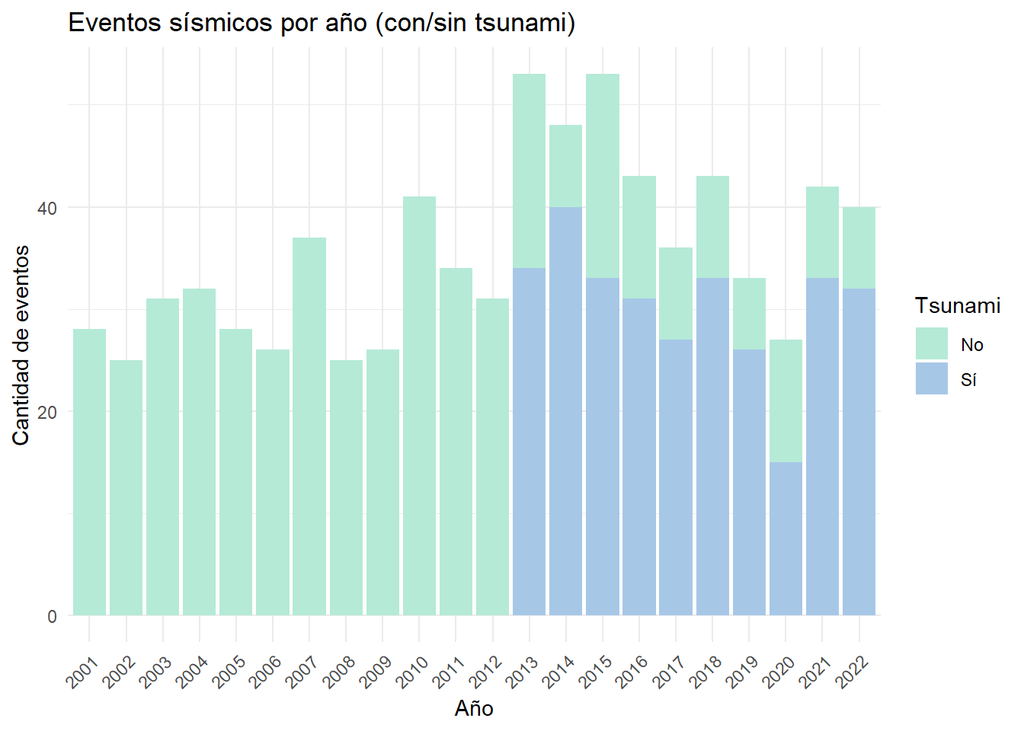

```
       No Sí
  2001 28  0
  2002 25  0
  2003 31  0
  2004 32  0
  2005 28  0
  2006 26  0
  2007 37  0
  2008 25  0
  2009 26  0
  2010 41  0
  2011 34  0
  2012 31  0
  2013 19 34
  2014  8 40
  2015 20 33
  2016 12 31
  2017  9 27
  2018 10 33
  2019  7 26
  2020 12 15
  2021  9 33
  2022  8 32
```

*Análisis*: A partir del año 2013 se observa un cambio claro en la distribución de eventos sísmicos con respecto a la presencia de tsunamis. Entre 2001 y 2012, todos los eventos registrados fueron sin tsunami. A partir de 2013, los eventos con tsunami aparecen y en varios años superan en cantidad a los eventos sin tsunami (por ejemplo, en 2014, 2018 y 2021). Este cambio podría reflejar una mejora en la capacidad de detección, una modificación en los criterios de clasificación o un patrón geofísico que debería ser analizado.

## Mapa Geográfico

A continuación se presenta un mapa interactivo que permite visualizar la distribución espacial de los eventos sísmicos registrados.

En él, el tamaño de cada marcador representa la magnitud del evento, el color de borde indica si estuvo o no asociado a un tsunami, y el color de relleno refleja la profundidad. Esta visualización permite integrar múltiples variables en un solo plano, facilitando la interpretación geográfica de los patrones observados.

**Mapa eventos con tsunami**

[interactive chart not shown]

Observando este mapa se refuerzan algunos conceptos observados anteriormente.

## Conclusión

Al analizar los datos, no se encontraron diferencias relevantes en la *magnitud* entre los eventos que generaron tsunami y aquellos que no. Esto indica que la magnitud, por sí sola, no resulta un buen indicador para anticipar la ocurrencia de un tsunami. La *profundidad* que se observa con colores más fuertes en caso de ser mayor y menos fuertes cuando es menor, aunque en promedio es mayor en eventos con tsunami, tampoco mostró diferencias estadísticamente significativas, por lo que podría influir pero no resulta determinante. En cambio, sí se evidencian diferencias en las intensidades: los eventos con tsunami presentan mayores niveles de *CDI*, lo que indica una percepción más intensa por parte de la población, mientras que los valores de *MMI* tienden a ser más altos en eventos sin tsunami, lo que sugiere que los tsunamis pueden estar presentes incluso en sismos de menor intensidad instrumental, posiblemente por su ubicación o características particular.